# Case Study 1

```r
str(EDSTATS)
```

```
## 'data.frame':    234 obs. of  31 variables:
##  $ CountryCode                                      : chr  "ABW" "ADO" "AFG" "AGO" ...
##  $ Long.Name                                        : chr  "Aruba" "Principality of Andorra" "Islamic State of Afghanistan" "People's Republic of Angola" ...
##  $ Income.Group                                     : chr  "High income: nonOECD" "High income: nonOECD" "Low income" "Lower middle income" ...
##  $ Region                                           : chr  "Latin America & Caribbean" "Europe & Central Asia" "South Asia" "Sub-Saharan Africa" ...
##  $ Lending.category                                 : chr  "" "" "IDA" "IDA" ...
##  $ Other.groups                                     : chr  "" "" "HIPC" "" ...
##  $ Currency.Unit                                    : chr  "Aruban florin" "Euro" "Afghan afghani" "Angolan kwanza" ...
##  $ Latest.population.census                         : chr  "2000" "Register based" "1979" "1970" ...
##  $ Latest.household.survey                          : chr  "" "" "MICS, 2003" "MICS, 2001, MIS, 2006/07" ...
##  $ Special.Notes                                    : chr  "" "" "Fiscal year end: March 20; reporting period for national accounts data: FY." "" ...
##  $ National.accounts.base.year                      : chr  "1995" "" "2002/2003" "1997" ...
##  $ National.accounts.reference.year                 : int  NA NA NA NA 1996 NA NA 1996 NA NA ...
##  $ System.of.National.Accounts                      : int  NA NA NA NA 1993 NA 1993 1993 NA NA ...
##  $ SNA.price.valuation                              : chr  "" "" "VAB" "VAP" ...
```

[output cut: 17 more lines]

```r
table(EDSTATS$CountryCode)
```

```
##
## ABW ADO AFG AGO ALB ARE ARG ARM ASM ATG AUS AUT AZE BDI BEL BEN BFA BGD
##   1   1   1   1   1   1   1   1   1   1   1   1   1   1   1   1   1   1
## BGR BHR BHS BIH BLR BLZ BMU BOL BRA BRB BRN BTN BWA CAF CAN CHE CHI CHL
##   1   1   1   1   1   1   1   1   1   1   1   1   1   1   1   1   1   1
## CHN CIV CMR COG COL COM CPV CRI CUB CYM CYP CZE DEU DJI DMA DNK DOM DZA
##   1   1   1   1   1   1   1   1   1   1   1   1   1   1   1   1   1   1
## EAP EAS ECA ECS ECU EGY EMU ERI ESP EST ETH FIN FJI FRA FRO FSM GAB GBR
##   1   1   1   1   1   1   1   1   1   1   1   1   1   1   1   1   1   1
## GEO GHA GIN GMB GNB GNQ GRC GRD GRL GTM GUM GUY HIC HKG HND HPC HRV HTI
##   1   1   1   1   1   1   1   1   1   1   1   1   1   1   1   1   1   1
## HUN IDN IMY IND IRL IRN IRQ ISL ISR ITA JAM JOR JPN KAZ KEN KGZ KHM KIR
##   1   1   1   1   1   1   1   1   1   1   1   1   1   1   1   1   1   1
## KNA KOR KSV KWT LAC LAO LBN LBR LBY LCA LCN LDC LIC LIE LKA LMC LMY LSO
##   1   1   1   1   1   1   1   1   1   1   1   1   1   1   1   1   1   1
## LTU LUX LVA MAC MAR MCO MDA MDG MDV MEA MEX MHL MIC MKD MLI MLT MMR MNA
##   1   1   1   1   1   1   1   1   1   1   1   1   1   1   1   1   1   1
## MNE MNG MNP MOZ MRT MUS MWI MYS NAC NAM NCL NER NGA NIC NLD NOC NOR NPL
##   1   1   1   1   1   1   1   1   1   1   1   1   1   1   1   1   1   1
## NZL OEC OMN PAK PAN PER PHL PLW PNG POL PRI PRK PRT PRY PYF QAT ROM RUS
##   1   1   1   1   1   1   1   1   1   1   1   1   1   1   1   1   1   1
## RWA SAS SAU SDN SEN SGP SLB SLE SLV SMR SOM SRB SSA SSF STP SUR SVK SVN
##   1   1   1   1   1   1   1   1   1   1   1   1   1   1   1   1   1   1
## SWE SWZ SYC SYR TCA TCD TGO THA TJK TKM TMP TON TTO TUN TUR TUV TZA UGA
##   1   1   1   1   1   1   1   1   1   1   1   1   1   1   1   1   1   1
## UKR UMC URY USA UZB VCT VEN VIR VNM VUT WBG WLD WSM YEM ZAF ZAR ZMB ZWE
##   1   1   1   1   1   1   1   1   1   1   1   1   1   1   1   1   1   1
```

There are no rows that have blank CountryCode so there is no need to look into deleting rows. However, there are many columns to this data set, and we would only like to analyze the CountryCode, Long.Name, and Income.Group fields.

```r
EDSTATS <- select(EDSTATS, CountryCode, Long.Name, Income.Group)
table(EDSTATS$Long.Name)
```

```
##
##                                                            American Samoa
##                                                                         1
##                                                       Antigua and Barbuda
##                                                                         1
##                                                    Arab Republic of Egypt
##                                                                         1
##                                                        Argentine Republic
##                                                                         1
##                                                                     Aruba
##                                                                         1
##                                                                  Barbados
##                                                                         1
##                                                                    Belize
##                                                                         1
##                                                    Bosnia and Herzegovina
##                                                                         1
##                                                         Brunei Darussalam
##                                                                         1
##                                                              Burkina Faso
##                                                                         1
##                                                                    Canada
##                                                                         1
##                                                            Cayman Islands
##                                                                         1
##                                                  Central African Republic
##                                                                         1
##                                                           Channel Islands
##                                                                         1
##                                                 Commonwealth of Australia
##                                                                         1
##                                                  Commonwealth of Dominica
##                                                                         1
##                                               Commonwealth of The Bahamas
##                                                                         1
##                              Commonwealth of the Northern Mariana Islands
##                                                                         1
##                                                            Czech Republic
##                                                                         1
##                                     Democratic People's Republic of Korea
```

[output cut: 414 more lines]

```
##                                                                         1
##                                                     United Mexican States
##                                                                         1
##                                               United Republic of Tanzania
##                                                                         1
##                                                  United States of America
##                                                                         1
##                                                       Upper middle income
##                                                                         1
##                                       Virgin Islands of the United States
##                                                                         1
##                                                        West Bank and Gaza
##                                                                         1
##                                                                     World
##                                                                         1
```

```r
table(EDSTATS$Income.Group)
```

```
##
##                      High income: nonOECD    High income: OECD
##                   24                   37                   30
##           Low income  Lower middle income  Upper middle income
##                   40                   56                   47
```

```r
# Notice, there are 24 blanks in Income.Group column.
```

The data are ready to analyze.

## Part 1: Merging Data

### Merge the data based on the country shortcode. How many of the IDs match?

```r
merged <- merge(GDP, EDSTATS, by.x = "COUNTRY_CODE", by.y = "CountryCode", all = FALSE)
nrow(merged)
```

```
## [1] 189
```

There are 189 Country shortcode IDs that matched between the GDP and the Education data.

## Part 2: Sorting Data

### Sort the data frame in ascending order by GDP (so United States is last). What is the 13th country in the resulting data frame?

```r
mergedsort <- merged[order(merged$USD_MIL, decreasing = FALSE),]
mergedsort[13,]
```

```
##    COUNTRY_CODE RANKING             ECONOMY USD_MIL COMMENTS
## 93          KNA     178 St. Kitts and Nevis     767
##              Long.Name        Income.Group
## 93 St. Kitts and Nevis Upper middle income
```

The 13th country with the lowest GDP in millions of US dollars is St. Kitts and Nevis (Country Code KNA).

## Part 3: Average GDP Rankings

### What are the average GDP rankings for the “High Income: OECD” and “High Income: OECD” groups?

```r
mean(mergedsort$RANKING[mergedsort$Income.Group == "High income: OECD"])
```

```
## [1] 32.96667
```

```r
mean(mergedsort$RANKING[mergedsort$Income.Group == "High income: nonOECD"])
```

```
## [1] 91.91304
```

The average GDP ranking for the “High income: OECD” group is 32.96667, and the average GDP ranking for the “High income: nonOECD” group is 91.91304.

## Part 4: Plotting Data

### Plot the GDP for all of the countries. Use ggplot2 to color your plot by Income Group.

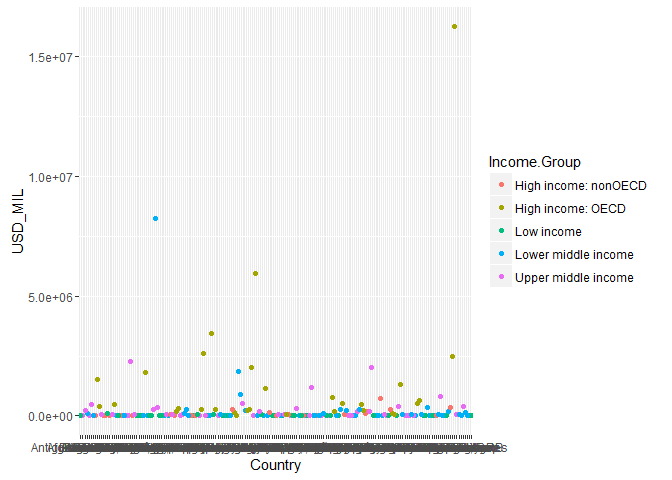

```r
ggplot(mergedsort)+ geom_point(aes(x=ECONOMY,y=USD_MIL,colour=Income.Group))+labs(x = "Country")
```

## Part 5: Quantiling Data

### Cut the GDP ranking into 5 separate quantile groups. Make a table versus Income.Group. How many countries are Lower middle income but among the 38 nations with highest GDP?

```r
mergedsort$QUANTILE <- cut(mergedsort$RANKING, breaks = 5)
table(mergedsort$QUANTILE, mergedsort$Income.Group)
```

```
##
##                High income: nonOECD High income: OECD Low income
##   (0.811,38.8]                    4                18          0
##   (38.8,76.6]                     5                10          1
##   (76.6,114]                      8                 1          9
##   (114,152]                       4                 1         16
##   (152,190]                       2                 0         11
##
##                Lower middle income Upper middle income
##   (0.811,38.8]                   5                  11
##   (38.8,76.6]                   13                   9
##   (76.6,114]                    12                   8
##   (114,152]                      8                   8
##   (152,190]                     16                   9
```

```r
mergedsort[ mergedsort$Income.Group == "Lower middle income" & mergedsort$RANKING <= 38,]
```

```
##     COUNTRY_CODE RANKING          ECONOMY USD_MIL COMMENTS
## 51           EGY      38 Egypt, Arab Rep.  262832
## 165          THA      31         Thailand  365966
## 77           IDN      16        Indonesia  878043
## 78           IND      10            India 1841710
## 34           CHN       2            China 8227103
##                      Long.Name        Income.Group     QUANTILE
## 51      Arab Republic of Egypt Lower middle income (0.811,38.8]
## 165        Kingdom of Thailand Lower middle income (0.811,38.8]
## 77       Republic of Indonesia Lower middle income (0.811,38.8]
## 78           Republic of India Lower middle income (0.811,38.8]
## 34  People's Republic of China Lower middle income (0.811,38.8]
```

There are five countries that are Lower middle income but among the 38 nations with highest GDP. These countries are Arab Republic of Egypt, Thailand, Indonesia, India, and China.

## Conclusion

This analysis provided useful outcomes in regards to the countries with higher GDP but have a lower middle income group. This analysis also resulted in a plot of countries by their GDP and Income Group.